# 4 Reaction Times

## 4.1 The Data

For this chapter, we will be using the data from Wagenmakers et al. (2008) - Experiment 1 (also reanalyzed by Heathcote and Love 2012), that contains responses and response times for several participants in two conditions (where instructions emphasized either **speed** or **accuracy**). Using the same procedure as the authors, we excluded all trials with uninterpretable response time, i.e., responses that are too fast (<180 ms) or too slow (>2 sec instead of >3 sec, see Thériault et al. 2024 for a discussion on outlier removal).

```julia
using Downloads, CSV, DataFrames
using Turing, Distributions, SequentialSamplingModels
using GLMakie

df = CSV.read(Downloads.download("https://raw.githubusercontent.com/DominiqueMakowski/CognitiveModels/main/data/wagenmakers2008.csv"), DataFrame)

# Show 10 first rows
first(df, 10)
```

10×5 DataFrame

| Row | Participant Int64 | Condition String15 | RT Float64 | Error Bool | Frequency String15 |
| --- | --- | --- | --- | --- | --- |
| 1 | 1 | Speed | 0.7 | false | Low |
| 2 | 1 | Speed | 0.392 | true | Very Low |
| 3 | 1 | Speed | 0.46 | false | Very Low |
| 4 | 1 | Speed | 0.455 | false | Very Low |
| 5 | 1 | Speed | 0.505 | true | Low |
| 6 | 1 | Speed | 0.773 | false | High |
| 7 | 1 | Speed | 0.39 | false | High |
| 8 | 1 | Speed | 0.587 | true | Low |
| 9 | 1 | Speed | 0.603 | false | Low |
| 10 | 1 | Speed | 0.435 | false | High |

In the previous chapter, we modelled the error rate (the probability of making an error) using a logistic model, and observed that it was higher in the `"Speed"` condition. But how about speed? We are going to first take interest in the RT of **Correct** answers only (as we can assume that errors are underpinned by a different *generative process*).

After filtering out the errors, we create a new column, `Accuracy`, which is the “binarization” of the `Condition` column, and is equal to 1 when the condition is `"Accuracy"` and 0 when it is `"Speed"`.

```julia
df = df[df.Error .== 0, :]
df.Accuracy = df.Condition .== "Accuracy"
```

**Code Tip**

Note the usage of *vectorization* `.==` as we want to compare each element of the `Condition` vector to the target `"Accuracy"`.

[output not shown]

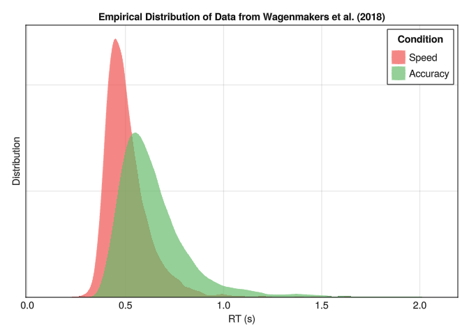

```julia
function plot_distribution(df, title="Empirical Distribution of Data from Wagenmakers et al. (2018)")
    fig = Figure()
    ax = Axis(fig[1, 1], title=title,
        xlabel="RT (s)",
        ylabel="Distribution",
        yticksvisible=false,
        xticksvisible=false,
        yticklabelsvisible=false)
    Makie.density!(df[df.Condition .== "Speed", :RT], color=("#EF5350", 0.7), label = "Speed")
    Makie.density!(df[df.Condition .== "Accuracy", :RT], color=("#66BB6A", 0.7), label = "Accuracy")
    Makie.axislegend("Condition"; position=:rt)
    Makie.ylims!(ax, (0, nothing))
    return fig
end

plot_distribution(df, "Empirical Distribution of Data from Wagenmakers et al. (2018)")
```

## 4.2 Descriptive Models

**Note**

### 4.2.1 Gaussian (aka *Linear*) Model

A linear model is the most common type of model. It aims at predicting the **mean** $\mu$ of the outcome variable using a **Normal** (aka *Gaussian*) distribution for the residuals. In other words, it models the outcome $y$ as a Normal distribution with a mean $\mu$ that is itself hte result of a linear function of the predictors $X$ and a variance $\sigma$ that is constant across all values of the predictors. It can be written as $y = Normal(\mu, \sigma)$, where $\mu = intercept + slope * X$.

In order to fit a Linear Model for RTs, we need to set a prior on all these parameters, namely: - The variance $\sigma$ (correspondong to the “spread” of RTs) - The mean $\mu$ for the intercept (i.e., at the reference condition which is in our case `"Speed"`) - The effect of the condition (the slope).

#### Model Specification

```julia
@model function model_Gaussian(rt; condition=nothing)

    # Set priors on variance, intercept and effect of condition
    σ ~ truncated(Normal(0, 0.5); lower=0)

    μ_intercept ~ truncated(Normal(0, 1); lower=0)
    μ_condition ~ Normal(0, 0.3)

    for i in 1:length(rt)
        μ = μ_intercept + μ_condition * condition[i]
        rt[i] ~ Normal(μ, σ)
    end
end


model = model_Gaussian(df.RT; condition=df.Accuracy)
chain_Gaussian = sample(model, NUTS(), 400)
```

```julia
# Summary (95% CI)
hpd(chain_Gaussian; alpha=0.05)
```

```
HPD
   parameters     lower     upper
       Symbol   Float64   Float64
            σ    0.1655    0.1704
  μ_intercept    0.5070    0.5162
  μ_condition    0.1312    0.1438
```

The effect of Condition is significant, people are on average slower (higher RT) when condition is `"Accuracy"`. But is our model good?

#### Posterior Predictive Check

```julia
pred = predict(model_Gaussian([(missing) for i in 1:length(df.RT)], condition=df.Accuracy), chain_Gaussian)
pred = Array(pred)
```

[output not shown]

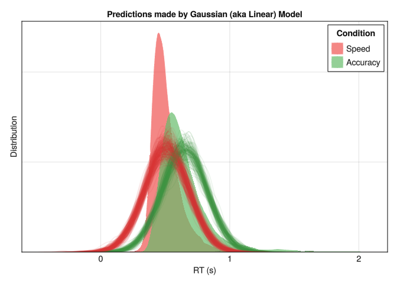

```julia
fig = plot_distribution(df, "Predictions made by Gaussian (aka Linear) Model")
for i in 1:length(chain_Gaussian)
    lines!(Makie.KernelDensity.kde(pred[:, i]), color=ifelse(df.Accuracy[i] == 1, "#388E3C", "#D32F2F"), alpha=0.1)
end
fig
```

### 4.2.2 Scaled Gaussian Model

The previous model, despite its poor fit to the data, suggests that the mean RT is higher for the `Accuracy` condition. But it seems like the distribution is also *wider* (response time is more variable). Typical linear model estimate only one value for sigma $\sigma$ for the whole model, hence the requirement for **homoscedasticity**.

**Note**

**Homoscedasticity**, or homogeneity of variances, is the assumption of similar variances accross different values of predictors. It is important in linear models as only one value for sigma $\sigma$ is estimated.

Is it possible to set sigma $\sigma$ as a parameter that would depend on the condition, in the same way as mu $\mu$? In Julia, this is very simple.

All we need is to set sigma $\sigma$ as the result of a linear function, such as $\sigma = intercept + slope * condition$. This means setting a prior on the intercept of sigma $\sigma$ (in our case, the variance in the reference condition) and a prior on how much this variance changes for the other condition. This change can, by definition, be positive or negative (i.e., the other condition can have either a biggger or a smaller variance), so the prior over the effect of condition should ideally allow for positive and negative values (e.g., `σ_condition ~ Normal(0, 0.1)`).

But this leads to an **important problem**.

**Important**

The combination of an intercept and a (possible negative) slope for sigma $\sigma$ technically allows for negative variance values, which is impossible (distributions cannot have a negative variance). This issue is one of the most important to address when setting up complex models for RTs.

Indeed, even if we set a very narrow prior on the intercept of sigma $\sigma$ to fix it at for instance **0.14**, and a narrow prior on the effect of condition, say $Normal(0, 0.001)$, an effect of condition of **-0.15** is still possible (albeit with very low probability). And such effect would lead to a sigma $\sigma$ of **0.14 - 0.15 = -0.01**, which would lead to an error (and this will often happen as the sampling process does explore unlikely regions of the parameter space).

#### Solution 1: Directional Effect of Condition

One possible (but not recommended) solution is to simply make it impossible for the effect of condition to be negative by *Truncating* the prior to a lower bound of 0. This can work in our case, because we know that the comparison condition is likely to have a higher variance than the reference condition (the intercept) - and if it wasn’t the case, we could have changed the reference factor. However, this is not a good practice as we are enforcing a very strong a priori specific direction of the effect, which is not always justified.

```julia
@model function model_ScaledlGaussian1(rt; condition=nothing)

    # Priors
    μ_intercept ~ truncated(Normal(0, 1); lower=0)
    μ_condition ~ Normal(0, 0.3)

    σ_intercept ~ truncated(Normal(0, 0.5); lower=0)  # Same prior as previously
    σ_condition ~ truncated(Normal(0, 0.1); lower=0)  # Enforce positivity

    for i in 1:length(rt)
        μ = μ_intercept + μ_condition * condition[i]
        σ = σ_intercept + σ_condition * condition[i]
        rt[i] ~ Normal(μ, σ)
    end
end

model = model_ScaledlGaussian1(df.RT; condition=df.Accuracy)
chain_ScaledGaussian = sample(model, NUTS(), 400)
```

```julia
# Summary (95% CI)
hpd(chain_ScaledGaussian; alpha=0.05)
```

```
HPD
   parameters     lower     upper
       Symbol   Float64   Float64
  μ_intercept    0.5085    0.5152
  μ_condition    0.1326    0.1453
  σ_intercept    0.1220    0.1272
  σ_condition    0.0714    0.0801
```

We can see that the effect of condition on sigma $\sigma$ is significantly positive: the variance is higher in the `Accuracy` condition as compared to the `Speed` condition.

#### Solution 2: Avoid Exploring Negative Variance Values

The other trick is to force the sampling algorithm to avoid exploring negative variance values (when sigma $\sigma$ < 0). This can be done by adding a conditional statement when sigma $\sigma$ is negative to avoid trying this value and erroring, and instead returning an infinitely low model probability (`-Inf`) to push away the exploration of this impossible region.

```julia
@model function model_ScaledlGaussian(rt; condition=nothing)

    # Priors
    μ_intercept ~ truncated(Normal(0, 1); lower=0)
    μ_condition ~ Normal(0, 0.3)

    σ_intercept ~ truncated(Normal(0, 0.5); lower=0)
    σ_condition ~ Normal(0, 0.1)

    for i in 1:length(rt)
        μ = μ_intercept + μ_condition * condition[i]
        σ = σ_intercept + σ_condition * condition[i]
        if σ < 0  # Avoid negative variance values
            Turing.@addlogprob! -Inf
            return nothing
        end
        rt[i] ~ Normal(μ, σ)
    end
end

model = model_ScaledlGaussian(df.RT; condition=df.Accuracy)
chain_ScaledGaussian = sample(model, NUTS(), 400)
```

```julia
hpd(chain_ScaledGaussian; alpha=0.05)
```

```
HPD
   parameters     lower     upper
       Symbol   Float64   Float64
  μ_intercept    0.5079    0.5146
  μ_condition    0.1317    0.1449
  σ_intercept    0.1222    0.1270
  σ_condition    0.0716    0.0804
```

[output not shown]

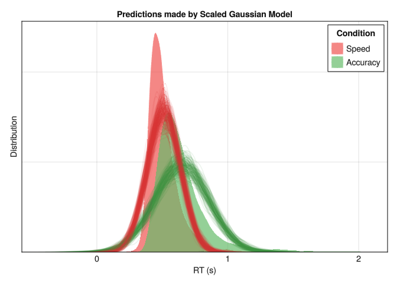

```julia
pred = predict(model_ScaledlGaussian([(missing) for i in 1:length(df.RT)], condition=df.Accuracy), chain_ScaledGaussian)
pred = Array(pred)

fig = plot_distribution(df, "Predictions made by Scaled Gaussian Model")
for i in 1:length(chain_ScaledGaussian)
    lines!(Makie.KernelDensity.kde(pred[:, i]), color=ifelse(df.Accuracy[i] == 1, "#388E3C", "#D32F2F"), alpha=0.1)
end
fig
```

Although relaxing the homoscedasticity assumption is a good step forward, allowing us to make **richer conclusions** and better capturing the data. Despite that, the Gaussian model stil seem to be a poor fit to the data.

### 4.2.3 The Problem with Linear Models

Reaction time (RTs) have been traditionally modeled using traditional linear models and their derived statistical tests such as *t*-test and ANOVAs. Importantly, linear models - by definition - will try to predict the *mean* of the outcome variable by estimating the “best fitting” *Normal* distribution. In the context of reaction times (RTs), this is not ideal, as RTs typically exhibit a non-normal distribution, skewed towards the left with a long tail towards the right. This means that the parameters of a Normal distribution (mean $\mu$ and standard deviation $\sigma$) are not good descriptors of the data.

[figure not shown]

> Linear models try to find the best fitting Normal distribution for the data. However, for reaction times, even the best fitting Normal distribution (in red) does not capture well the actual data (in grey).

A popular mitigation method to account for the non-normality of RTs is to transform the data, using for instance the popular *log-transform*. However, this practice should be avoided as it leads to various issues, including loss of power and distorted results interpretation (Lo and Andrews 2015; Schramm and Rouder 2019). Instead, rather than applying arbitrary data transformation, it would be better to swap the Normal distribution used by the model for a more appropriate one that can better capture the characteristics of a RT distribution.

### 4.2.4 Shifted LogNormal Model

One of the obvious candidate alternative to the log-transformation would be to use a model with a Log-transformed Normal distribution. A LogNormal distribution is a distribution of a random variable whose logarithm is normally distributed. A **Shifted** LogNormal model introduces a shift (a delay) parameter *tau* $\tau$ that corresponds to the minimum “starting time” of the response process.

We need to set a prior for this parameter, which is usually truncated between 0 (to exclude negative minimum times) and the minimum RT of the data (the logic being that the minimum delay for response must be lower than the faster response actually observed).

While $Uniform(0, min(RT))$ is a common choice of prior, it is not ideal as it implies that all values between 0 and the minimum RT are equally likely, which is not the case. Indeed, psychology research has shown that such minimum response time for Humans is often betwen 100 and 250 ms. Moreover, in our case, we explicitly removed all RTs below 180 ms, suggesting that the minimum response time is more likely to approach 180 ms than 0 ms.

#### Prior on Minimum RT

Instead of a $Uniform$ prior, we will use a $Gamma(1.1, 11)$ distribution (truncated at min. RT), as this particular parameterization reflects the low probability of very low minimum RTs (near 0) and a steadily increasing probability for increasing times.

[output not shown]

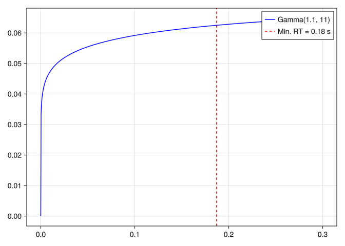

```julia
xaxis = range(0, 0.3, 1000)
fig = lines(xaxis, pdf.(Gamma(1.1, 11), xaxis); color=:blue, label="Gamma(1.1, 11)")
vlines!([minimum(df.RT)]; color="red", linestyle=:dash, label="Min. RT = 0.18 s")
axislegend()
fig
```

#### Model Specification

```julia
@model function model_LogNormal(rt; min_rt=minimum(df.RT), condition=nothing)

    # Priors
    τ ~ truncated(Gamma(1.1, 11); upper=min_rt)

    μ_intercept ~ Normal(0, exp(1))  # On the log-scale: exp(μ) to get value in seconds
    μ_condition ~ Normal(0, exp(0.3))

    σ_intercept ~ truncated(Normal(0, 0.5); lower=0)
    σ_condition ~ Normal(0, 0.1)

    for i in 1:length(rt)
        μ = μ_intercept + μ_condition * condition[i]
        σ = σ_intercept + σ_condition * condition[i]
        if σ < 0  # Avoid negative variance values
            Turing.@addlogprob! -Inf
            return nothing
        end
        rt[i] ~ ShiftedLogNormal(μ, σ, τ)
    end
end

model = model_LogNormal(df.RT; condition=df.Accuracy)
chain_LogNormal = sample(model, NUTS(), 400)
```

#### Interpretation

```julia
hpd(chain_LogNormal; alpha=0.05)
```

```
HPD
   parameters     lower     upper
       Symbol   Float64   Float64
            τ    0.1724    0.1790
  μ_intercept   -1.1604   -1.1313
  μ_condition    0.3130    0.3418
  σ_intercept    0.3090    0.3226
  σ_condition    0.0334    0.0521
```

[output not shown]

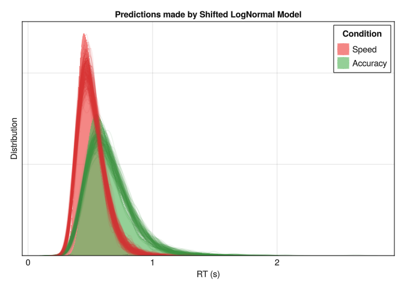

```julia
pred = predict(model_LogNormal([(missing) for i in 1:length(df.RT)]; condition=df.Accuracy), chain_LogNormal)
pred = Array(pred)

fig = plot_distribution(df, "Predictions made by Shifted LogNormal Model")
for i in 1:length(chain_LogNormal)
    lines!(Makie.KernelDensity.kde(pred[:, i]), color=ifelse(df.Accuracy[i] == 1, "#388E3C", "#D32F2F"), alpha=0.1)
end
fig
```

This model provides a much better fit to the data, and confirms that the `Accuracy` condition is associated with higher RTs and higher variability (i.e., a larger distribution width).

### 4.2.5 ExGaussian Model

Another popular model to describe RTs uses the **ExGaussian** distribution, i.e., the *Exponentially-modified Gaussian* distribution (Balota and Yap 2011; Matzke and Wagenmakers 2009).

This distribution is a convolution of normal and exponential distributions and has three parameters, namely *mu* $\mu$ and *sigma* $\sigma$ - the mean and standard deviation of the Gaussian distribution - and *tau* $\tau$ - the exponential component of the distribution (note that although denoted by the same letter, it does not correspond directly to a shift of the distribution). Intuitively, these parameters reflect the centrality, the width and the tail dominance, respectively.

[figure not shown]

Beyond the descriptive value of these types of models, some have tried to interpret their parameters in terms of **cognitive mechanisms**, arguing for instance that changes in the Gaussian components ($\mu$ and $\sigma$) reflect changes in attentional processes [e.g., “the time required for organization and execution of the motor response”; Hohle (1965)], whereas changes in the exponential component ($\tau$) reflect changes in intentional (i.e., decision-related) processes (Kieffaber et al. 2006). However, Matzke and Wagenmakers (2009) demonstrate that there is likely no direct correspondence between ex-Gaussian parameters and cognitive mechanisms, and underline their value primarily as **descriptive tools**, rather than models of cognition *per se*.

Descriptively, the three parameters can be interpreted as:

- **Mu** $\mu$: The location / centrality of the RTs. Would correspond to the mean in a symmetrical distribution.
- **Sigma** $\sigma$: The variability and dispersion of the RTs. Akin to the standard deviation in normal distributions.
- **Tau** $\tau$: Tail weight / skewness of the distribution.

**Important**

Note that these parameters are not independent with respect to distribution characteristics, such as the empirical mean and SD. Below is an example of different distributions with the same location (*mu* $\mu$) and dispersion (*sigma* $\sigma$) parameters. Although only the tail weight parameter (*tau* $\tau$) is changed, the whole distribution appears to shift is centre of mass. Hence, one should be careful note to interpret the values of *mu* $\mu$ directly as the “mean” or the distribution peak and *sigma* $\sigma$ as the SD or the “width”.

[figure not shown]

## 4.3 Generative Models (DDM)

- [**Drift Diffusion Model (DDM) in R: A Tutorial**](https://dominiquemakowski.github.io/easyRT/articles/ddm.html)

## 4.6 Additional Resources

- [**Lindelov’s overview of RT models**](https://lindeloev.github.io/shiny-rt/): An absolute must-read.
- [**De Boeck & Jeon (2019)**](https://www.frontiersin.org/articles/10.3389/fpsyg.2019.00102/full): A paper providing an overview of RT models.
- https://github.com/vasishth/bayescogsci

Balota, David A, and Melvin J Yap. 2011. “Moving Beyond the Mean in Studies of Mental Chronometry: The Power of Response Time Distributional Analyses.” *Current Directions in Psychological Science* 20 (3): 160–66.

Heathcote, Andrew, and Jonathon Love. 2012. “Linear Deterministic Accumulator Models of Simple Choice.” *Frontiers in Psychology* 3: 292.

Hohle, Raymond H. 1965. “Inferred Components of Reaction Times as Functions of Foreperiod Duration.” *Journal of Experimental Psychology* 69 (4): 382.

Kieffaber, Paul D, Emily S Kappenman, Misty Bodkins, Anantha Shekhar, Brian F O’Donnell, and William P Hetrick. 2006. “Switch and Maintenance of Task Set in Schizophrenia.” *Schizophrenia Research* 84 (2-3): 345–58.

Lo, Steson, and Sally Andrews. 2015. “To Transform or Not to Transform: Using Generalized Linear Mixed Models to Analyse Reaction Time Data.” *Frontiers in Psychology* 6: 1171.

Matzke, Dora, and Eric-Jan Wagenmakers. 2009. “Psychological Interpretation of the Ex-Gaussian and Shifted Wald Parameters: A Diffusion Model Analysis.” *Psychonomic Bulletin & Review* 16: 798–817.

Schramm, Pele, and Jeffrey N Rouder. 2019. “Are Reaction Time Transformations Really Beneficial?”

Thériault, Rémi, Mattan S Ben-Shachar, Indrajeet Patil, Daniel Lüdecke, Brenton M Wiernik, and Dominique Makowski. 2024. “Check Your Outliers! An Introduction to Identifying Statistical Outliers in r with Easystats.” *Behavior Research Methods* 56 (4): 4162–72.

Wagenmakers, Eric-Jan, Roger Ratcliff, Pablo Gomez, and Gail McKoon. 2008. “A Diffusion Model Account of Criterion Shifts in the Lexical Decision Task.” *Journal of Memory and Language* 58 (1): 140–59.